# Using BCPA v. 1.3 on a one-dimensional variable

Elie Gurarie

November 14, 2018

# Comments

The BCPA was originally formulated to analyze irregular movement data collected on marine mammals, but in essence it simply reduced movement data (X-Y-Time) to a univariate time-series. There are - in my opinoin - better (i.e. more informative and more robust) tools for dealing with movement data specifically, (e.g. at https://github.com/EliGurarie/smoove), but the BCPA might still be useful for irregular univariate time series. An example (again from marine mammals) is depth data. A recent update to BCPA makes this analysis somewhat smoother. Here is an example on simulated data.

Note - to date this is available only on the GitHub version of BCPA, i.e. the first step is:

```r
require(devtools)
install_github("EliGurarie/bcpa")
```

The code for this example can also be found in the help file for the `WindowSweep()` function.

# Analysis

## Depth data simulation

Load `bcpa`, and a few other handy packages:

```r
require(magrittr)
require(lubridate)
require(bcpa)
```

We simulate some data with four phases / three change points: surface to medium to deep to surface, that occur at fixed times.

```r
n.obs <- 100
time = (Sys.time() - dhours(runif(n.obs, 0, n.obs))) %>% sort

d1 <- 50; d2 <- 100
t1 <- 25; t2 <- 65; t3 <- 85
sd1 <- 1; sd2 <- 5; sd3 <- 10

dtime <- difftime(time, min(time), units="hours") %>% as.numeric
phases <- cut(dtime, c(-1, t1, t2, t3, 200), labels = c("P1","P2","P3","P4"))
means <- c(0,d1,d2,0)[phases]
sds <- c(sd1,sd2,sd3,sd1)[phases]
depth <- rnorm(n.obs,means, sds)
# make all depths positive!
depth <- abs(depth)
mydata <- data.frame(time, depth)
```

The structure of the data is very simple:

```r
head(mydata)
```

```
##                  time      depth
## 1 2022-05-20 07:14:26 0.32192527
## 2 2022-05-20 07:50:53 0.78383894
## 3 2022-05-20 08:18:26 1.57572752
## 4 2022-05-20 08:46:33 0.64289931
## 5 2022-05-20 09:02:00 0.08976065
## 6 2022-05-20 10:22:20 0.27655075
```

Plot simulated depth data

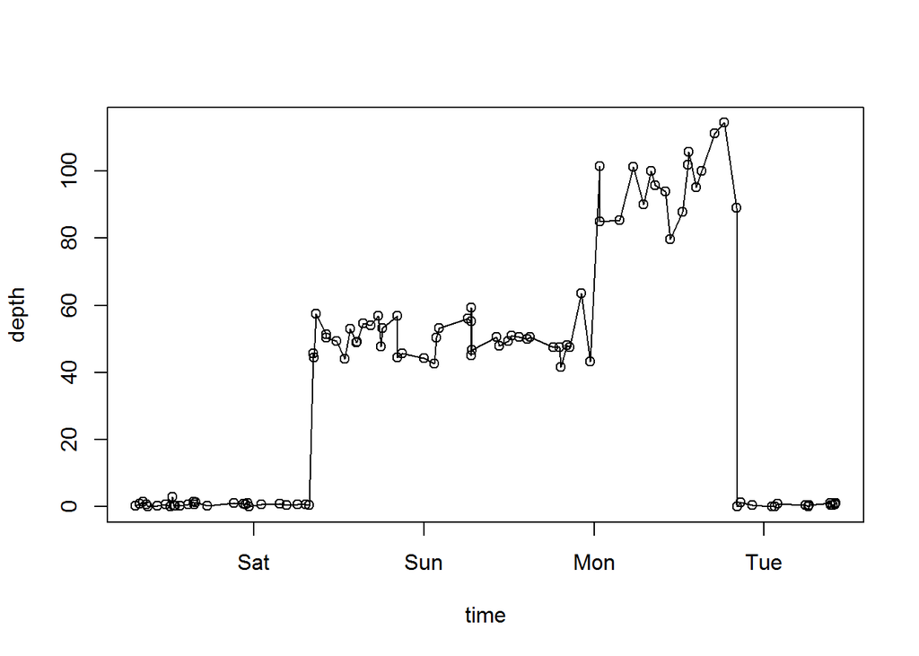

```r
with(mydata, plot(time, depth, type = "o"))
```

Perform the window sweep. Note that you specify the response variable (`depth`) and the time varible (`time`):

```r
depth.ws <- WindowSweep(mydata, variable = "depth", time.var = "time", windowsize = 25, windowstep = 1, progress=FALSE)
```

Here are some plots and the summary of the change point analysis:

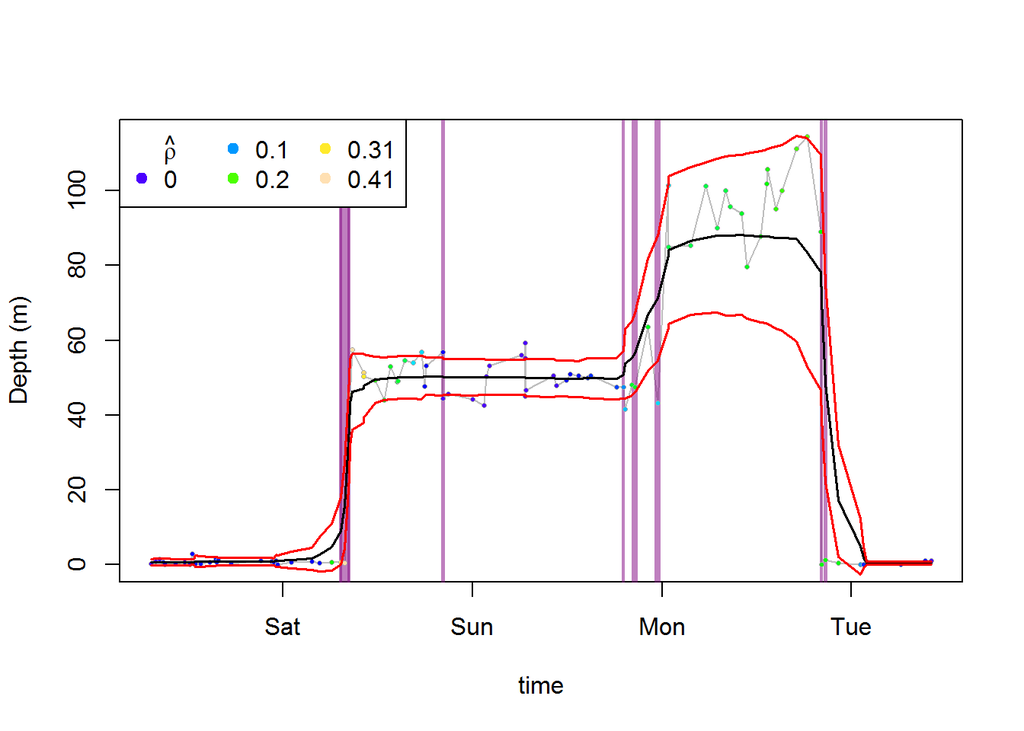

```r
plot(depth.ws, ylab = "Depth (m)")
```

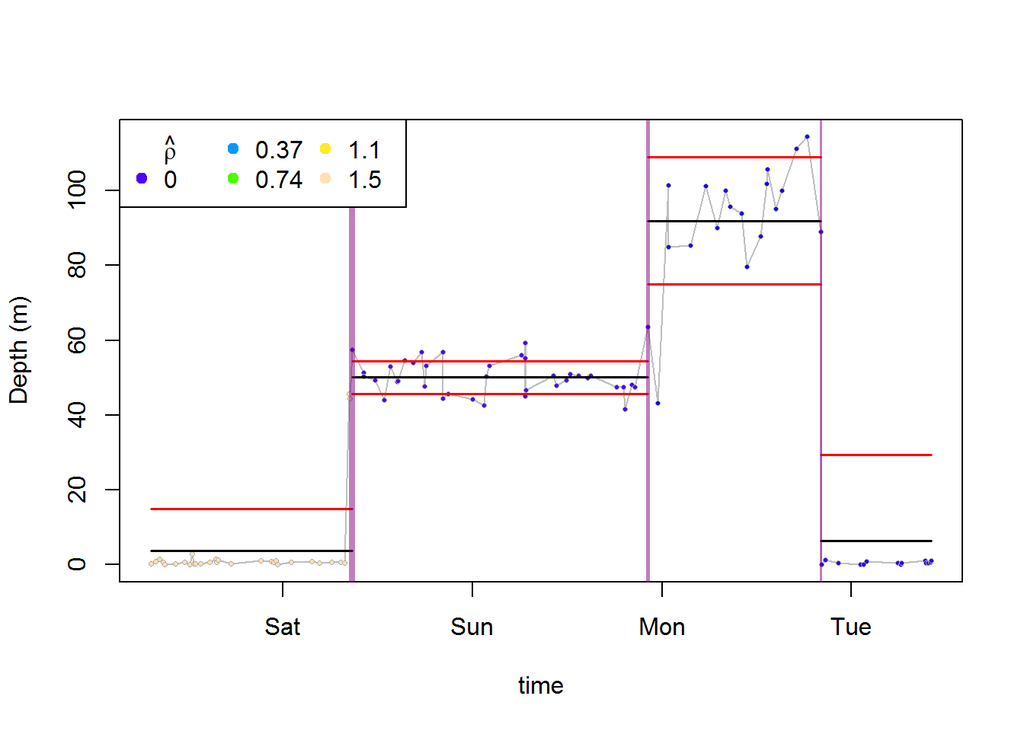

```r
plot(depth.ws, type = "flat", cluster = 8, ylab = "Depth (m)")
```

```r
ChangePointSummary(depth.ws, cluster = 8)
```

```
## $breaks
##   X1   middle size modelmode        middle.POSIX
## 1  1 25.46224   27         4 2022-05-21 08:35:45
## 2  2 62.47157   18         4 2022-05-22 21:24:14
## 3  3 84.46078   12         4 2022-05-23 19:12:38
##
## $phases
##         t.cut    mu.hat     s.hat      rho.hat       t0       t1 interval
## 1   (-1,25.5]  3.681865 11.256694 1.4733085237 -1.00000 25.46224 26.46224
## 2 (25.5,62.5] 50.063357  4.367361 0.0005596285 25.46224 62.47157 37.00933
## 3 (62.5,84.5] 91.941686 17.048889 0.0883214495 62.47157 84.46078 21.98921
## 4 (84.5,98.9]  6.434163 22.852427 0.0613947945 84.46078 98.86528 14.40450
```

This is a pretty artificial example, but it works well.